# 00-Data-Processing-Example

### Extract features in service area

Project the Hamilton DA zones to the same projection of the SoBi Service Area:

```r
hamilton_da_2016 <- st_transform(hamilton_da_2016, crs = st_crs(sobi_service))
```

Extract DAs in service area:

```r
hamilton_da_sobi <- hamilton_da_2016[st_as_sfc(bounding_box),]
```

Extract parks in service area:

```r
parks_sobi <- st_crop(parks, st_as_sfc(bounding_box))
```

```
attribute variables are assumed to be spatially constant throughout all geometries
```

Extract cemeteries in service area:

```r
cemeteries_sobi <- st_crop(cemeteries, st_as_sfc(bounding_box))
```

```
attribute variables are assumed to be spatially constant throughout all geometries
```

Extract environmentally sensitive areas in service area:

```r
esa_sobi <- st_crop(esa, st_as_sfc(bounding_box))
```

```
attribute variables are assumed to be spatially constant throughout all geometries
```

Extract golf courses in service area:

```r
golf_sobi <- st_crop(golf_courses, st_as_sfc(bounding_box))
```

```
attribute variables are assumed to be spatially constant throughout all geometries
```

Extract employment lands in service area:

```r
employment_sobi <- st_crop(employment_lands, st_as_sfc(bounding_box))
```

```
attribute variables are assumed to be spatially constant throughout all geometries
```

Extract railways in service area:

```r
railways_sobi <- st_crop(railways, st_as_sfc(bounding_box))
```

```
attribute variables are assumed to be spatially constant throughout all geometries
```

Extract municipal parking lots in service area:

```r
parking_sobi <- st_crop(municipal_parking, st_as_sfc(bounding_box))
```

```
attribute variables are assumed to be spatially constant throughout all geometries
```

Extract provincial highways in service area:

```r
highways_sobi <- st_crop(streets, st_as_sfc(bounding_box))
```

```
attribute variables are assumed to be spatially constant throughout all geometries
```

Extract educational institutions in service area:

```r
schools_sobi <- st_crop(schools, st_as_sfc(bounding_box))
```

```
attribute variables are assumed to be spatially constant throughout all geometries
```

Extract places of worship in service area:

```r
religious_sobi <- st_crop(religious_places, st_as_sfc(bounding_box))
```

```
attribute variables are assumed to be spatially constant throughout all geometries
```

Extract municipal service centres in service area:

```r
service_sobi <- st_crop(service_centres, st_as_sfc(bounding_box))
```

```
attribute variables are assumed to be spatially constant throughout all geometries
```

Extract recreation and community centres in service area:

```r
recreation_sobi <- st_crop(recreation_centres, st_as_sfc(bounding_box))
```

```
attribute variables are assumed to be spatially constant throughout all geometries
```

Extract indoor arenas in service area:

```r
arenas_sobi <- st_crop(arenas, st_as_sfc(bounding_box))
```

```
attribute variables are assumed to be spatially constant throughout all geometries
```

Extract educational institutions in service area:

```r
schools_sobi <- st_crop(schools, st_as_sfc(bounding_box))
```

```
attribute variables are assumed to be spatially constant throughout all geometries
```

Extract EMS stations in service area:

```r
ems_sobi <- st_crop(ems, st_as_sfc(bounding_box))
```

```
attribute variables are assumed to be spatially constant throughout all geometries
```

Extract fire stations in service area:

```r
fire_sobi <- st_crop(fire, st_as_sfc(bounding_box))
```

```
attribute variables are assumed to be spatially constant throughout all geometries
```

Extract police stations in service area:

```r
police_sobi <- st_crop(police, st_as_sfc(bounding_box))
```

```
attribute variables are assumed to be spatially constant throughout all geometries
```

Extract hospitals in service area:

```r
hospitals_sobi <- st_crop(hospitals, st_as_sfc(bounding_box))
```

```
attribute variables are assumed to be spatially constant throughout all geometries
```

### Read population

Read population table (2016 Census of Population, Population and Dwelling counts):

```r
population_da_2016 <- read_csv("T1901EN.csv") %>%
  transmute(DA = factor(`Geographic code`), population = `Population, 2016`)
```

[output not shown]

Join population table to DAs in service areas:

```r
hamilton_da_sobi <- hamilton_da_sobi %>%
  left_join(population_da_2016, by = "DA")
```

### Visualize geographical data

Plot population:

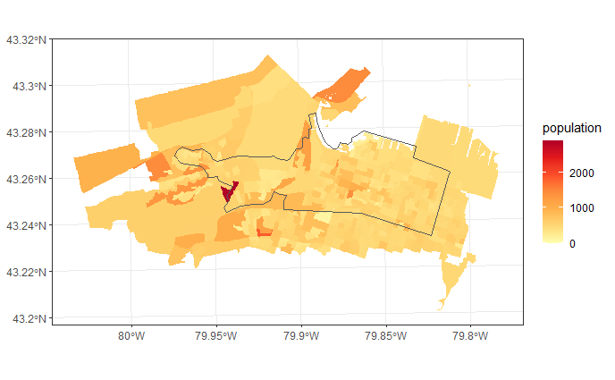

```r
ggplot() +
  geom_sf(data = hamilton_da_sobi,
          aes(fill = population),
          color = NA) +
  geom_sf(data = sobi_service,
          fill = NA) +
  scale_fill_distiller(palette = "YlOrRd", direction = 1)
```

Plot “Green” spaces:

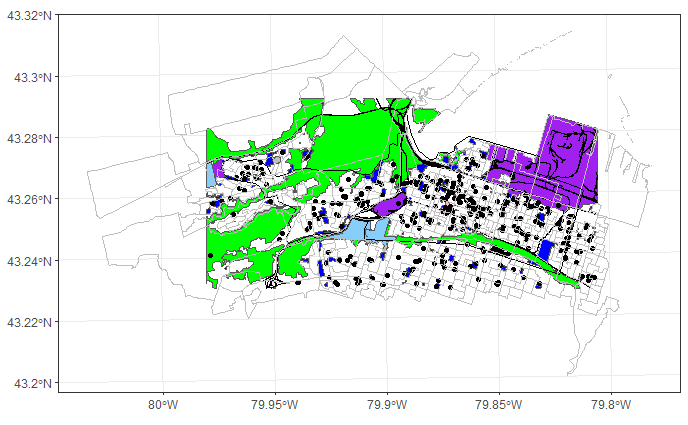

```r
ggplot() +
  geom_sf(data = parks_sobi,
          fill = "blue") +
  geom_sf(data = cemeteries_sobi,
          fill = "gray") +
  geom_sf(data = esa_sobi,
          fill = "green") +
  geom_sf(data = golf_sobi,
          fill = "lightskyblue") +
  geom_sf(data = employment_sobi,
          fill = "purple") +
  geom_sf(data = railways_sobi,
          fill = "wheat") +
  geom_sf(data = parking_sobi,
          fill = "lightpink") +
  geom_sf(data = highways_sobi,
          fill = "orange") +
  geom_sf(data = schools_sobi,
          fill = "red") +
  geom_sf(data = religious_sobi,
          fill = "pink") +
  geom_sf(data = service_sobi,
          fill = "yellow") +
  geom_sf(data = recreation_sobi,
          fill = "yellow") +
  geom_sf(data = arenas_sobi,
          fill = "yellow") +
  geom_sf(data = ems_sobi,
          fill = "yellow") +
  geom_sf(data = ems_sobi,
          fill = "yellow") +
  geom_sf(data = fire_sobi,
          fill = "yellow") +
  geom_sf(data = police_sobi,
          fill = "yellow") +
  geom_sf(data = hospitals_sobi,
          fill = "yellow") +
  geom_sf(data = sobi_service,
          fill = NA,
          color = "black") +
  geom_sf(data = hamilton_da_sobi,
          fill = NA,
          color = "gray") +
  scale_fill_distiller(palette = "YlOrRd", direction = 1)
```

### Prepare geographical data for interpolation

Union of the “green space” features:

```r
parks_sobi <- st_combine(parks_sobi)
cemeteries_sobi <- st_combine(cemeteries_sobi)
esa_sobi <- st_combine(esa_sobi)
golf_sobi <- st_combine(golf_sobi)
employment_sobi <- st_combine(employment_sobi)
railways_sobi <- st_combine(railways_sobi)
parking_sobi <- st_combine(parking_sobi)
highways_sobi <- st_combine(highways_sobi)
schools_sobi <- st_combine(schools_sobi)
religious_sobi <- st_combine(religious_sobi)
service_sobi <- st_combine(service_sobi)
recreation_sobi <- st_combine(recreation_sobi)
arenas_sobi <- st_combine(arenas_sobi)
ems_sobi <- st_combine(ems_sobi)
fire_sobi <- st_combine(fire_sobi)
police_sobi <- st_combine(police_sobi)
hospitals_sobi <- st_combine(hospitals_sobi)
```

Check that the topology is valid:

```r
st_is_valid(parks_sobi)
```

```
[1] FALSE
```

```r
st_is_valid(cemeteries_sobi)
```

```
[1] TRUE
```

```r
st_is_valid(esa_sobi)
```

```
[1] FALSE
```

```r
st_is_valid(golf_sobi)
```

```
[1] TRUE
```

```r
st_is_valid(employment_sobi)
```

```
[1] TRUE
```

```r
st_is_valid(railways_sobi)
```

```
[1] TRUE
```

```r
st_is_valid(parking_sobi)
```

```
[1] FALSE
```

```r
st_is_valid(highways_sobi)
```

```
[1] TRUE
```

```r
st_is_valid(schools_sobi)
```

```
[1] TRUE
```

```r
st_is_valid(religious_sobi)
```

```
[1] TRUE
```

```r
st_is_valid(service_sobi)
```

```
[1] TRUE
```

```r
st_is_valid(recreation_sobi)
```

```
[1] TRUE
```

```r
st_is_valid(arenas_sobi)
```

```
[1] TRUE
```

```r
st_is_valid(ems_sobi)
```

```
[1] TRUE
```

```r
st_is_valid(fire_sobi)
```

```
[1] TRUE
```

```r
st_is_valid(police_sobi)
```

```
[1] TRUE
```

```r
st_is_valid(hospitals_sobi)
```

```
[1] TRUE
```

Make valid:

```r
parks_sobi <- st_make_valid(parks_sobi)
esa_sobi <- st_make_valid(esa_sobi)
parking_sobi <- st_make_valid(parking_sobi)
```

### Remove all features that are not population from the DAs

Remove the parks from the DAs (use `st_difference()`):

```r
hamilton_da_sobi_clean <- st_difference(hamilton_da_sobi, parks_sobi)
```

```
attribute variables are assumed to be spatially constant throughout all geometries
```

Remove the cemeteries from the DAs (use `st_difference()`):

```r
hamilton_da_sobi_clean <- st_difference(hamilton_da_sobi_clean, cemeteries_sobi)
```

```
attribute variables are assumed to be spatially constant throughout all geometries
```

Remove environmentally sensitive areas from the DAs (use `st_difference()`):

```r
hamilton_da_sobi_clean <- st_difference(hamilton_da_sobi_clean, esa_sobi)
```

```
attribute variables are assumed to be spatially constant throughout all geometries
```

Remove golf courses from the DAs (use `st_difference()`):

```r
hamilton_da_sobi_clean <- st_difference(hamilton_da_sobi_clean, golf_sobi)
```

```
attribute variables are assumed to be spatially constant throughout all geometries
```

Remove employment lands from the DAs (use `st_difference()`):

```r
hamilton_da_sobi_clean <- st_difference(hamilton_da_sobi_clean, employment_sobi)
```

```
attribute variables are assumed to be spatially constant throughout all geometries
```

Remove railways from the DAs (use `st_difference()`):

```r
hamilton_da_sobi_clean <- st_difference(hamilton_da_sobi_clean, railways_sobi)
```

```
attribute variables are assumed to be spatially constant throughout all geometries
```

Remove municipal parking lots from the DAs (use `st_difference()`):

```r
hamilton_da_sobi_clean <- st_difference(hamilton_da_sobi_clean, parking_sobi)
```

```
attribute variables are assumed to be spatially constant throughout all geometries
```

Remove provincial highways from the DAs (use `st_difference()`):

```r
hamilton_da_sobi_clean <- st_difference(hamilton_da_sobi_clean, highways_sobi)
```

```
attribute variables are assumed to be spatially constant throughout all geometries
```

Remove educational institutions from the DAs (use `st_difference()`):

```r
hamilton_da_sobi_clean <- st_difference(hamilton_da_sobi_clean, schools_sobi)
```

```
attribute variables are assumed to be spatially constant throughout all geometries
```

Remove places of worship from the DAs (use `st_difference()`):

```r
hamilton_da_sobi_clean <- st_difference(hamilton_da_sobi_clean, religious_sobi)
```

```
attribute variables are assumed to be spatially constant throughout all geometries
```

Remove municipal service centres from the DAs (use `st_difference()`):

```r
hamilton_da_sobi_clean <- st_difference(hamilton_da_sobi_clean, service_sobi)
```

```
attribute variables are assumed to be spatially constant throughout all geometries
```

Remove recreation and community centres from the DAs (use `st_difference()`):

```r
hamilton_da_sobi_clean <- st_difference(hamilton_da_sobi_clean, recreation_sobi)
```

```
attribute variables are assumed to be spatially constant throughout all geometries
```

Remove arenas from the DAs (use `st_difference()`):

```r
hamilton_da_sobi_clean <- st_difference(hamilton_da_sobi_clean, arenas_sobi)
```

```
attribute variables are assumed to be spatially constant throughout all geometries
```

Remove EMS stations from the DAs (use `st_difference()`):

```r
hamilton_da_sobi_clean <- st_difference(hamilton_da_sobi_clean, ems_sobi)
```

```
attribute variables are assumed to be spatially constant throughout all geometries
```

Remove fire stations from the DAs (use `st_difference()`):

```r
hamilton_da_sobi_clean <- st_difference(hamilton_da_sobi_clean, fire_sobi)
```

```
attribute variables are assumed to be spatially constant throughout all geometries
```

Remove police stations from the DAs (use `st_difference()`):

```r
hamilton_da_sobi_clean <- st_difference(hamilton_da_sobi_clean, police_sobi)
```

```
attribute variables are assumed to be spatially constant throughout all geometries
```

Remove hospitals from the DAs (use `st_difference()`):

```r
hamilton_da_sobi_clean <- st_difference(hamilton_da_sobi_clean, hospitals_sobi)
```

```
attribute variables are assumed to be spatially constant throughout all geometries
```

Plot the new DAs (minus green) and compare to original DAs:

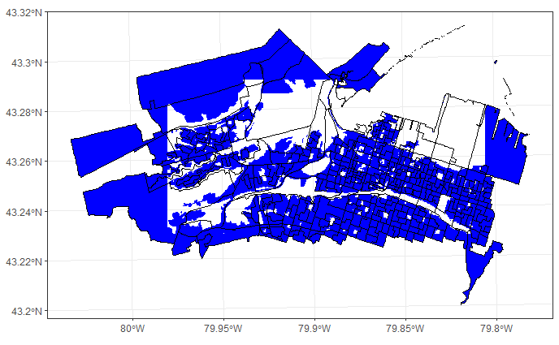

```r
ggplot() +
  geom_sf(data = hamilton_da_sobi_clean,
          color = NA,
          fill = "blue") +
  geom_sf(data = hamilton_da_sobi,
          fill = NA,
          color = "black")
```